# Lab 4 Notebook_ANOVA

#### DATA: states

##### ANOVA

Level of measurement: The dependent variable must be interval-ratio. The independent variable must be nominal or ordinal, with more than two categories to be tested.

Example: Test whether the poverty rate differs across regions of the U.S.

Dependent variable: poverty Independent variable: region

##### General syntax:

1. Look at the means by category: aggregate(y~x, dataset, mean)
2. Use the aov function to compute anova and store the results in the variable anova.results: anova.results <- aov(y~x, dataset)
3. Show the table of results: summary(anova.results)

```r
# Syntax for this example:
aggregate(POVERTY~REGION, states, mean)
```

| REGION | POVERTY |
| --- | --- |
| Midwest | 9.841657 |
| Northeast | 9.599987 |
| South | 13.785706 |
| West | 11.946144 |

```r
anova.results <- aov(POVERTY~REGION, states)
summary(anova.results)
```

```
            Df Sum Sq Mean Sq F value   Pr(>F)
REGION       3  148.3   49.42   8.284 0.000164 ***
Residuals   46  274.4    5.97
---
Signif. codes:  0 ‘***’ 0.001 ‘**’ 0.01 ‘*’ 0.05 ‘.’ 0.1 ‘ ’ 1
```

##### Interpreting the results

Does F-obtained (F value) fall in the critical region? In other words, is the difference statistically significant? If the value of Pr(>F) is smaller than alpha (typically 0.05), we will reject the null hypothesis and there is a statistically significant difference among the four poverty rates represented by the four regions. If the value of Pr(>F) is greater than 0.05, we will fail to reject the null hypothesis.

We examined poverty by region. There is a statistically significant difference in poverty by regions. F(3,46) = 8.284, p = 0.000164, smaller than the significance level 0.05. South has the highest level of poverty rate 13.79% while Northeast has the lowest level of poverty rate 9.59%.

#### Advanced

##### Tukey HSD post-hoc test

ANOVAs will determine if there are significant differences between groups. But it does not tell us where these differences lay. Tukey test will determine where the differences are, allow you to pinpoint what exact groups are actualy significantly different from each other.

```r
TukeyHSD(anova.results) # Create a set of confidence intervals on the differences between the means of the levels of a factor
```

```
  Tukey multiple comparisons of means
    95% family-wise confidence level

Fit: aov(formula = POVERTY ~ REGION, data = states)

$REGION
                        diff        lwr       upr     p adj
Northeast-Midwest -0.2416703 -2.9593537 2.4760131 0.9952469
South-Midwest      3.9440486  1.3827869 6.5053102 0.0009151
West-Midwest       2.1044865 -0.5018448 4.7108178 0.1521781
South-Northeast    4.1857189  1.5625180 6.8089198 0.0005748
West-Northeast     2.3461568 -0.3210673 5.0133810 0.1027843
West-South        -1.8395620 -4.3472189 0.6680948 0.2198595
```

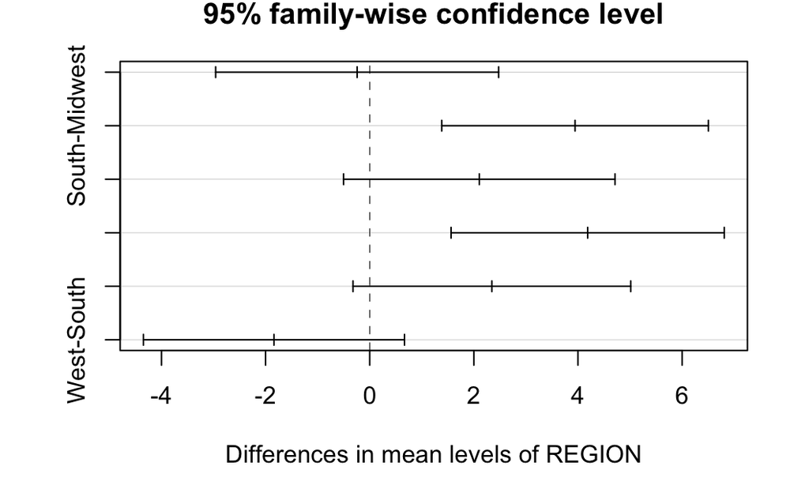

```r
plot(TukeyHSD(anova.results))
```

##### A two-way between subjects ANOVA:

```r
aov2 <- aov(BWT ~ RACE + SMOKE + RACE:SMOKE, data = lowbwt)
summary(aov2)
```

```
             Df   Sum Sq Mean Sq F value   Pr(>F)
RACE          1  3846362 3846362   8.168 0.004754 **
SMOKE         1  7377302 7377302  15.665 0.000108 ***
RACE:SMOKE    1  1570882 1570882   3.336 0.069404 .
Residuals   185 87122507  470932
---
Signif. codes:  0 ‘***’ 0.001 ‘**’ 0.01 ‘*’ 0.05 ‘.’ 0.1 ‘ ’ 1
```

### Assignment 5:

Data frame for this assignment: country

1. Conduct the appropriate hypothesis test to determine if there is a statistically significant difference in female life expectancy 2004 based on HDI Category.
1. Use variables at the appropriate level of measurement.
2. Show R syntax.
3. Show results tables.
4. Report technical results.
5. In one paragraph, comment on the implications of the result of the test. Speculate. Is this relationship cause and effect; why or why not?
2. If you wanted to conduct an ANOVA hypothesis test, but both of your variables were interval-ratio, which of the following tasks would you need to complete in order to be able to conduct the test? Select only one answer:
1. Recode the dependent variable into a nominal or ordinal variable.
2. Recode the independent variable into a nominal or ordinal variable.
3. Recode both the dependent and independent variables into nominal or ordinal variables.
4. Conduct the test with the two interval-ratio level variables.
5. Abandon the analysis.